# Nonblood mtDNA drift analysis

Mike Spencer Chapman

2026-09-16

## Set file paths.

Manually set these file paths before running the script - this needs a local copy of the hg19 genome file

```r
#genomeFile is set in config.R
source(here::here("config.R")) #sets root_dir, genomeFile, project paths and my_markdown_theme
set_markdown_figure_defaults() #larger default figure size for on-screen reading
```

Set the secondary file paths used throughout the script. This data is all included in the github repository.

```r
#Source the necessary functions - included in the repo
source(paste0(root_dir,"/data/mito_mutations_blood_functions.R"))

#Set the key file paths using the root dir
tree_file_paths = list.files(paste0(root_dir,"/data/tree_files"),pattern=".tree",full.names = T)
ref_file=paste0(root_dir,"/data/Samples_metadata_ref.csv")
nonblood_ref_file=paste0(root_dir,"/data/metadata/non_blood_metadata.xlsx")
colony_info_file=paste0(root_dir,"/data/metadata/colonyinfo_AX001_KX001_KX002_KX003_TX001_TX002_CB001.txt")
plots_dir=notebook_plots_dir("Nonblood_mtDNA_drift_analysis")

# read in the trinucleotide context data
mtdna_trinuc_freq_path=paste0(root_dir,"/data/mtDNA_trinuc_freqs_coding_dloop_heavy_light.Rds")
mtdna_trinuc_freq <- readRDS(mtdna_trinuc_freq_path)

# set regions for coding and dloop regions - important for the mutation profiles
coding_region <- 577:16023
d_loop_region <- c(1:576,16024:16569)

#Set the basic plotting theme for ggplot2
#my_markdown_theme is defined in config.R


#Read in the mitochondrial copy number data
mito_cn=read.csv(paste0(root_dir,"/data/whole_genome_coverage_pileup_and_bedtools_annotated.csv"),header=T)%>%
  dplyr::rename("pileup_median_mtDNA_coverage"=pilup_median_mtDNA_coverage) #This column has a typo

#Import individual level metadata for the adult and foetal blood samples
ref_df<-readxl::read_excel(nonblood_ref_file) #Import metadata relating to all individuals studied
colony_info<-read.delim(colony_info_file) #Import colony-level data for the lymphoid dataset as there are multiple different cell types
```

Set some other variables and colour schemes used in the script. e.g. defining which initials are used as keys for which dataset. (out of interest, these are generally the initials of the principal scientist who generated that data, e.g. KY = “Kenichi Yoshida”)

```r
#Define the dataframe for converting IDs between my IDs, and Andrew's for the different datasets
translate=data.frame(dataset=c("KY","HL","SO","PR","LM","NW","lymph","EM"),
                     al_ref=c("lung_organoid","colon","colon_ibd","muty_mutant","endometrium","blood_MPN","immune","blood_emily"))

muty_samples=c("PD44887","PD44888","PD44889","PD44890","PD44891")

#Define a set of 'black-listed' mutations - these are sets of artefacts that recurrently slip through the filters
#This is often due to haplotype-specific artefacts that map as SNVs
exclude_muts=c("MT_302_A_C","MT_311_C_T","MT_456_C_T","MT_567_A_C","MT_574_A_C","MT_8270_C_T","MT_16170_A_C","MT_16181_A_C","MT_16182_A_C","MT_16183_A_C","MT_16189_T_C")

#Set up objects for colour schemes and renaming tissues for plots
mut_type_cols<-c("#00468B","#925E9F","#925E9F","#810F7C","black","#E10C04","black")
names(mut_type_cols)<-c("Missense","Nonsense","Truncating","Stop_loss","Non-Coding","Synonymous","Overall")

name_conversion_vec=c("Normal blood","Lymphoid","MPN","Colon","IBD-affected\nColon","MUTYH-mutant\nColon","Endometrium","Bronchial\nepithelium")
names(name_conversion_vec)=c("blood","lymph","NW","HL","SO","PR","LM","KY")
tissue_cols<-c("#96e97c","#fd81c8","#145a6a","#65e6f9","#781486","#5f70cc","#aea2eb","#1d6d1f")
names(tissue_cols)<-name_conversion_vec
```

## IMPORT ALL DATASETS

```r
all_cohorts_plus_CML<-c("KY","HL","SO","PR","LM","NW","CML","lymph","blood")
all_cohorts<-c("KY","HL","SO","PR","LM","NW","lymph","blood")

all_mito_datasets<-lapply(all_cohorts_plus_CML,function(dataset) {

  dataset_mito_data<-readRDS(paste0(root_dir,"/data/nonblood/mito_mutation_data_",dataset,".RDS"))
  CN_correlating_muts<-readRDS(paste0(root_dir,"/data/nonblood/CN_correlation_",dataset,".RDS"))

  rho_cut_off=0

  #Deal with the germline mutations (if not done already)
  dataset_mito_data<-Map(list=dataset_mito_data,exp_ID=names(dataset_mito_data),function(list,exp_ID) {
    if(is.null(list$germline_muts)) {
      list$germline_muts<-identify_germline(matrices=list$matrices,threshold=0.9)
      cat(list$germline_muts,sep="\n")
      list$matrices<-reverse_germline(matrices=list$matrices,threshold=0.9)
    }
    return(list)
  })

  #Sort out the names of the mutCN column
  dataset_mito_data<-lapply(dataset_mito_data,function(list) {
    colnames(list$matrices$implied_mutCN)<-stringr::str_split(colnames(list$matrices$implied_mutCN),pattern = '\\.\\.\\.',simplify=T)[,1]
    return(list)
  })

  #Add the CN correlating muts vector to each patient (slightly inefficient but programatically more straight-forward)
  dataset_mito_data<-lapply(dataset_mito_data,function(list) {
    list$CN_correlating_muts<-CN_correlating_muts
    return(list)
  })


  #cat("Adding the filtered VAF matrix.",sep="\n")

  #Annotate specific mutations with their most likely signature using the 'sig_ref' dataframe
  dataset_mito_data<-Map(list=dataset_mito_data,this_exp_ID=names(dataset_mito_data),function(list,this_exp_ID) {

    #cat(this_exp_ID,sep="\n")

    if(dataset=="lymph") {list$tree$tip.label<-unique(list$sample_shearwater_calls$sampleID)}

    mutCN_cutoff=25 #If the mitochondrial copy number is over 25, retain mutation even if is in the "CN correlating muts" list
    CN_correlating_mut_removal_mat=list$matrices$implied_mutCN>mutCN_cutoff|(matrix((!rownames(list$matrices$vaf)%in%CN_correlating_muts),ncol=1)%*%matrix(rep(1,ncol(list$matrices$vaf)),nrow=1))
    vaf.filt<-(list$matrices$vaf[,list$tree$tip.label]*list$matrices$SW[,list$tree$tip.label][,list$tree$tip.label]*CN_correlating_mut_removal_mat[,list$tree$tip.label])[!grepl("DEL|INS",rownames(list$matrices$vaf))&
                                                                                                                                                                            list$rho_vals>rho_cut_off&
                                                                                                                                                                            !rownames(list$matrices$vaf)%in%exclude_muts,]

    list$matrices$CN_correlating_mut_removal_mat<-CN_correlating_mut_removal_mat
    list$matrices$vaf.filt<-vaf.filt
    return(list)
  })

  if(dataset=="lymph") {
    dataset_mito_data<-Map(list=dataset_mito_data,exp_ID=names(dataset_mito_data),function(list,exp_ID) {
      if(!exp_ID=="TX001") {list$het_oocyte_muts<-c()}
      return(list)
    })
  }
  return(dataset_mito_data)
})
names(all_mito_datasets)<-all_cohorts_plus_CML
```

Convert this into tidy dataframe format. One dataframe per dataset.

```r
all_df_tidy<-Map(dataset=all_cohorts_plus_CML,dataset_mito_data=all_mito_datasets,function(dataset,dataset_mito_data) {
  cat(dataset,sep="\n")

  #Generate tidy data frame of samples, mutations and vafs
  mutCN_cutoff=25 #If the mitochondrial copy number is over 25, retain mutation even if is in the "CN correlating muts" list
  vaf_cut_off<-0.03
  rho_cut_off<-0
  CN_correlating_muts<-dataset_mito_data$CN_correlating_muts
  df_tidy<-dplyr::bind_rows(Map(list=dataset_mito_data,exp_ID=names(dataset_mito_data),function(list,exp_ID) {
    if(is.null(list)){stop(return(NULL))}
    CN_correlating_mut_removal_mat=list$matrices$CN_correlating_mut_removal_mat
    implied_mut_CN_tidy<-list$matrices$implied_mutCN%>%
      as.data.frame()%>%
      tibble::rownames_to_column(var="mut_ref")%>%
      tidyr::gather(key="Sample",value="implied_mut_CN",-mut_ref)
    df_tidy<-(list$matrices$vaf*list$matrices$SW*CN_correlating_mut_removal_mat)%>%
      as.data.frame()%>%
      tibble::rownames_to_column(var="mut_ref")%>%
      mutate(rho_val=list$rho_vals)%>%
      tidyr::gather(key="Sample",value="vaf",-mut_ref,-rho_val)

    comb_tidy<-left_join(df_tidy,implied_mut_CN_tidy,by=c("Sample","mut_ref"))%>%
      dplyr::filter(!grepl("DEL|INS",mut_ref) & !mut_ref%in%exclude_muts & !mut_ref%in%list$het_oocyte_muts)%>%
      dplyr::filter(vaf>=vaf_cut_off)%>%
      mutate(exp_ID=exp_ID)
    return(comb_tidy)
  }))

  #Filter the CN-correlating mutations - due to mis-mapping of nuclear reads.
  #There may be some genuine mutations at these sites, in which case the implied mutation copy number will be much higher than ~2 (here an arbitrary threshold of 8 is applied)
  df_tidy<-df_tidy%>%
    left_join(mito_cn,by="Sample")%>%
    mutate(implied_mut_CN=vaf*bedtools_mtDNA_genomes)%>%
    dplyr::filter(!(mut_ref%in%dataset_mito_data$CN_correlating_muts & implied_mut_CN<=mutCN_cutoff))

  return(df_tidy)
})
```

```
## KY
## HL
## SO
## PR
## LM
```

```
## NW
## CML
## lymph
## blood
```

### Enhance the tidy dataframe with ‘VAF bin’ info

Define the VAF ‘bins’ that will be used for comparing VAF distributions Can set this on a log scale, or as decile bins (used for the main analysis).

```r
log_scale=F
if(log_scale) {
  new_VAF_groups=c("<0.1%","0.1-0.2%","0.2-0.4%","0.4-0.8%","0.8-1.6%","1.6-3.1%","3.1-6.2%","6.2-12.5%","12.5-25%","25-50%",">50%")
  VAF_groups=data.frame(labels=new_VAF_groups,LL=c(0,2^(-10:-1)),UL=2^(-10:0))
} else {
  new_VAF_groups=paste0(100*seq(0,0.95,0.05),"-",100*seq(0.05,1,0.05),"%")
  VAF_groups=data.frame(labels=new_VAF_groups,LL=seq(0,0.95,0.05),UL=seq(0.05,1,0.05))
}

all_df_tidy<-lapply(all_df_tidy,function(df_tidy) {

  #Assign each observed VAF into its 'VAF group' bin
  df_tidy$VAF_group=sapply(df_tidy$vaf,function(vaf) {
    if(vaf==0) {
      return("Absent")
    } else {
      return(VAF_groups$labels[VAF_groups$LL<vaf & VAF_groups$UL>=vaf])
    }
  })
  return(df_tidy)
})
```

### Generate VAF distribution matrices

For each data set, generate a matrix where each row is an individual, and each column is a VAF bin The matrix is filled with the average number of mutations in that bin per sample If the number of samples is too low, this values will have a large degree of sampling error, therefore limit to individuals with >15 samples

```r
minimum_samples_to_include=15

#Iterate across samples/ VAF groups to get numbers of mutations per sample/ VAF group
VAF_distribution_mats<-Map(dataset_mito_data=all_mito_datasets[all_cohorts],df_tidy=all_df_tidy[all_cohorts],function(dataset_mito_data,df_tidy) {
  all_samples=dplyr::bind_rows(Map(list=dataset_mito_data,exp_ID=names(dataset_mito_data),function(list,exp_ID) data.frame(exp_ID=exp_ID,Sample=list$tree$tip.label)))
  samples_vaf_groups_df<-right_join(all_samples,tidyr::expand_grid(Sample=all_samples$Sample,VAF_group=new_VAF_groups),by="Sample")
  nmut_by_vaf_by_sample<-left_join(samples_vaf_groups_df,df_tidy%>%
                                     group_by(Sample,VAF_group)%>%
                                     dplyr::summarise(n=n(),.groups = "drop_last"),by=c("Sample","VAF_group"))%>%
    replace_na(replace = list(n=0))

    donors_to_include=names(dataset_mito_data)[sapply(dataset_mito_data,function(list) length(list$tree$tip.label)>=minimum_samples_to_include)]

  tissue_mat<-lapply(donors_to_include,function(this_exp_ID) {

    #Highly clonally related samples are not 'independent' measures of mtDNA mutation burden. Therefore, randomly select one of
    #any highly clonally related clades (those with >half of mutations related)
    mut_burden<-get_mut_burden(dataset_mito_data[[this_exp_ID]]$tree.ultra)[1]
    expanded_clade_nodes<-get_expanded_clade_nodes(tree=dataset_mito_data[[this_exp_ID]]$tree.ultra,min_samples=2,height_cut_off=mut_burden/2)
    samples_to_drop=unlist(lapply(expanded_clade_nodes$nodes,function(node) {
      clade_samples<-getTips(tree=dataset_mito_data[[this_exp_ID]]$tree.ultra,node)
      to_drop=sample(clade_samples,size=length(clade_samples)-1)
    }))

    donor_df<-nmut_by_vaf_by_sample%>%filter(exp_ID==this_exp_ID & !Sample%in%samples_to_drop)

    if(nrow(donor_df)>0) {
      donor_df%>%
        pivot_wider(names_from = Sample,values_from = n)%>%
        dplyr::select(-exp_ID)%>%
        tibble::column_to_rownames(var="VAF_group")%>%
        as.matrix()%>%rowMeans()%>%
        as.data.frame()%>%
        rlang::set_names(this_exp_ID)
    } else {
      NULL
    }

  })%>%bind_cols()%>%
    as.matrix()%>%t()

  return(tissue_mat)
})
```

Generate plots of these VAF distributions by individual

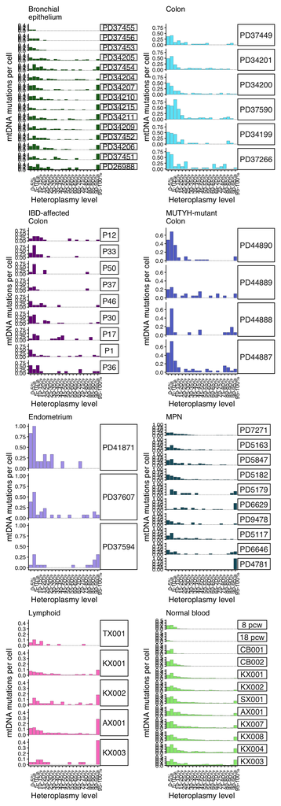

```r
# Now generate the plots one dataset at a time
all_VAF_distribution_plots=Map(mat=VAF_distribution_mats,dataset=all_cohorts,function(mat,dataset) {
  #cat(dataset,sep="\n")
  exp_ID_by_age<-ref_df%>%filter(ID%in%rownames(mat) & Cohort==dataset)%>%
    arrange(Age)%>%pull(ID)
  if(length(exp_ID_by_age)==0) {stop(return(NULL))}

  VAF_dist_plot<-as.data.frame(mat)%>%t()%>%
    as.data.frame()%>%tibble::rownames_to_column(var="VAF_group")%>%
    tidyr::gather(-VAF_group,key="exp_ID",value="n_per_sample")%>%
    ggplot(aes(x=factor(VAF_group,levels=new_VAF_groups),y=n_per_sample))+
    geom_bar(stat="identity",fill=tissue_cols[name_conversion_vec[dataset]],col="black",linewidth=0.1)+
    facet_grid(rows=vars(factor(exp_ID,levels=exp_ID_by_age)))+
    theme_classic()+
    my_markdown_theme+
    theme(axis.text.x=element_text(angle=90),strip.text.y=element_text(angle=0))+
    labs(x="Heteroplasmy level",y="mtDNA mutations per cell",title = name_conversion_vec[dataset])

  save_plot(filename=paste0(plots_dir,"VAF_dist_plot2_",dataset,".pdf"),VAF_dist_plot,width=2.5,height=(0.6*nrow(mat)))
  return(VAF_dist_plot)
})

wrap_plots(all_VAF_distribution_plots,ncol=2)
```

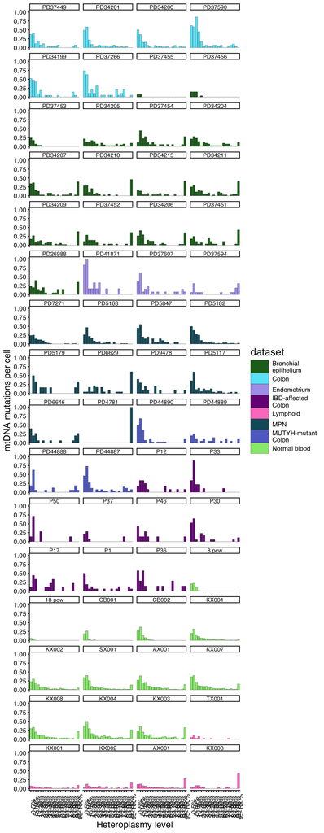

```r
# Now a single plot across all datasets
comb_VAF_distribution=Map(mat=VAF_distribution_mats,data_set=all_cohorts,function(mat,data_set) {
  #cat(data_set,sep="\n")
  exp_ID_by_age<-ref_df%>%filter(ID%in%rownames(mat) & Cohort==data_set)%>%
    arrange(Age)%>%pull(ID)
  if(length(exp_ID_by_age)==0) {stop(return(NULL))}

  as.data.frame(mat)%>%t()%>%
    as.data.frame()%>%tibble::rownames_to_column(var="VAF_group")%>%
    tidyr::gather(-VAF_group,key="exp_ID",value="n_per_sample")%>%
    dplyr::mutate(dataset=data_set)
})%>%dplyr::bind_rows()

cohort_exp_ID_by_age<-ref_df%>%
  mutate(cohort_exp_ID=paste(Cohort,ID,sep="_"))%>%
  filter(ID%in%comb_VAF_distribution$exp_ID)%>%arrange(Cohort,Age)%>%pull(cohort_exp_ID)
combined_VAF_dist_plot<-comb_VAF_distribution%>%
  mutate(cohort_exp_ID=factor(paste(dataset,exp_ID,sep="_"),levels=cohort_exp_ID_by_age))%>%
  mutate(dataset=name_conversion_vec[dataset])%>%
  ggplot(aes(fill=dataset,x=factor(VAF_group,levels=new_VAF_groups),y=n_per_sample))+
  geom_bar(stat="identity",col="black",linewidth=0.1)+
  facet_wrap(~cohort_exp_ID,ncol=4,
             labeller=labeller(cohort_exp_ID=function(x) {stringr::str_split(x,pattern="_",simplify=T)[,2]}))+
  scale_fill_manual(values=tissue_cols)+
  theme_classic()+
  my_markdown_theme+
  theme(axis.text.x=element_text(angle=90),
        strip.text=element_text(angle=0,size = 9, margin = margin(1,0.5,1,0.5)))+
  labs(x="Heteroplasmy level",y="mtDNA mutations per cell")
combined_VAF_dist_plot
```

```r
save_plot(filename=paste0(plots_dir,"combined_VAF_distirbution_plot.pdf"),combined_VAF_dist_plot,width=7,height=12)
```

This plot is a bit overwhelming to interpret. Once of the most interesting comparisons is between HSCs and lymphoid cells. We actually have data from lymphoid cells and HSCs from the SAME individuals. Lets just do a comparison of these 4 individuals.

This shows that lymphoid cells have MORE homoplasmic mutations per cell, but far fewer lower heteroplasmy mutations. This is consistent with a population bottleneck +/- a degree of selection.

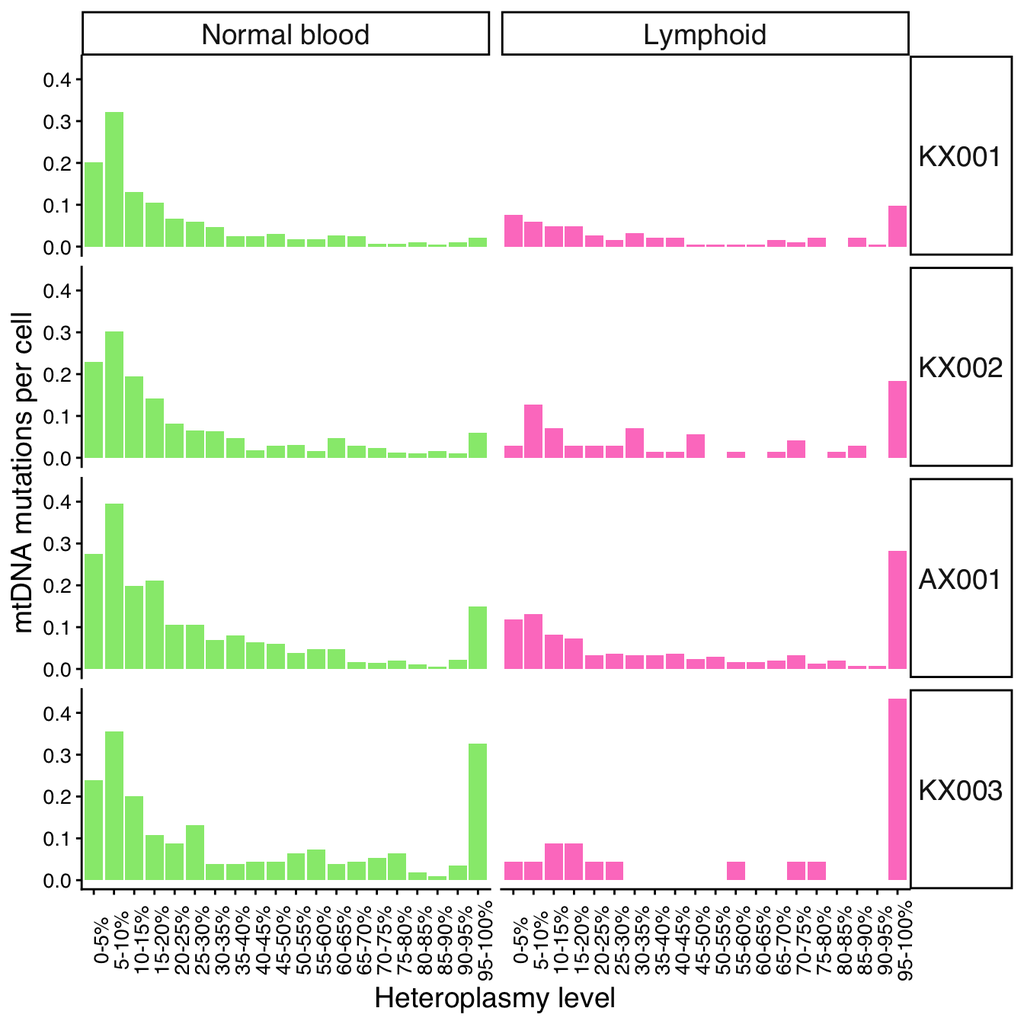

```r
both_dataset_IDs<-intersect(rownames(VAF_distribution_mats$lymph),rownames(VAF_distribution_mats$blood))
both_dataset_IDs<-ref_df%>%dplyr::filter(ID%in%both_dataset_IDs&Cohort=="blood")%>%arrange(Age)%>%pull(ID)

blood_lymph_common_data<-lapply(c("lymph","blood"),function(tissue) {
  as.data.frame(VAF_distribution_mats[[tissue]])%>%
    tibble::rownames_to_column(var="exp_ID")%>%
    tidyr::gather(-exp_ID,key="VAF_group",value=n_per_sample)%>%
    filter(exp_ID%in%both_dataset_IDs)%>%
    mutate(dataset=tissue,.before=1)
})%>%bind_rows()

blood_vs_lymph_VAF_distribution<-blood_lymph_common_data%>%
  mutate(dataset=factor(name_conversion_vec[dataset],levels=c("Normal blood","Lymphoid")),exp_ID=factor(exp_ID,levels=both_dataset_IDs))%>%
  ggplot(aes(x=factor(VAF_group,levels=new_VAF_groups),y=n_per_sample,fill=dataset))+
  geom_bar(stat="identity")+
  scale_fill_manual(values=tissue_cols)+
  facet_grid(exp_ID~dataset)+
  theme_classic()+
  my_markdown_theme+
  theme(axis.text.x=element_text(angle=90),strip.text.y=element_text(angle=0),legend.position="none")+
  labs(x="Heteroplasmy level",y="mtDNA mutations per cell")

blood_vs_lymph_VAF_distribution
```

```r
save_plot(filename=paste0(plots_dir,"blood_vs_lymph_VAF_dist.pdf"),blood_vs_lymph_VAF_distribution,width=3.3,height=2.5)
```

Let’s do a Kolmogorov Smirnov test to compare the distribution of mutations in the lymphocytes vs HSCs for each of these individuals. This shows that in all cases the heteroplasmy distributions are significantly different between the HSCs and the lymphocytes at the same time point. Later we’ll do a comparison that incorporates specific lymphocyte subsets.

```r
for(i in 1:length(both_dataset_IDs)) {
  this_ID<-both_dataset_IDs[i]

  blood_vafs<-all_df_tidy[["blood"]]%>%filter(exp_ID==this_ID)%>%pull(vaf)
  lymph_vafs<-all_df_tidy[["lymph"]]%>%filter(exp_ID==this_ID)%>%pull(vaf)
  ks.res<-ks.test(x=blood_vafs,y=lymph_vafs)
  print(ks.res)
}
```

```
##
##  Asymptotic two-sample Kolmogorov-Smirnov test
##
## data:  blood_vafs and lymph_vafs
## D = 0.26716, p-value = 1.397e-05
## alternative hypothesis: two-sided
##
##
##  Asymptotic two-sample Kolmogorov-Smirnov test
##
## data:  blood_vafs and lymph_vafs
## D = 0.31897, p-value = 9.119e-05
## alternative hypothesis: two-sided
```

```
##
##  Asymptotic two-sample Kolmogorov-Smirnov test
##
## data:  blood_vafs and lymph_vafs
## D = 0.24415, p-value = 3.973e-10
## alternative hypothesis: two-sided
```

```
##
##  Asymptotic two-sample Kolmogorov-Smirnov test
##
## data:  blood_vafs and lymph_vafs
## D = 0.39566, p-value = 0.003394
## alternative hypothesis: two-sided
```

### Generate tidy VAF distribution dataframe

Generate a single tidy dataframe with numbers of mutations in each VAF category per sample, with each VAF category as a separate row Because this doesn’t average across samples, can have a more liberal inclusion of individuals with fewer samples

```r
minimum_samples_to_include=8
VAF_distribution_by_sample_df<-Map(dataset=all_cohorts,dataset_mito_data=all_mito_datasets[all_cohorts],df_tidy=all_df_tidy[all_cohorts],function(dataset,dataset_mito_data,df_tidy) {
  all_samples=dplyr::bind_rows(Map(list=dataset_mito_data,exp_ID=names(dataset_mito_data),function(list,exp_ID) data.frame(exp_ID=exp_ID,Sample=list$tree$tip.label)))
  samples_vaf_groups_df<-right_join(all_samples,tidyr::expand_grid(Sample=all_samples$Sample,VAF_group=new_VAF_groups),by="Sample")
  nmut_by_vaf_by_sample<-left_join(samples_vaf_groups_df,df_tidy%>%
                                     group_by(Sample,VAF_group)%>%
                                     dplyr::summarise(n=n(),.groups = "drop_last"),by=c("Sample","VAF_group"))%>%
    replace_na(replace = list(n=0))


  donors_to_include=names(dataset_mito_data)[sapply(dataset_mito_data,function(list) length(list$tree$tip.label)>=minimum_samples_to_include)]

  tissue_df<-lapply(donors_to_include,function(this_exp_ID) {

    #Highly clonally related samples are not 'independent' measures of mtDNA mutation burden. Therefore, randomly select one of
    #any highly clonally related clades (those with >half of mutations related)
    mut_burden<-get_mut_burden(dataset_mito_data[[this_exp_ID]]$tree.ultra)[1]
    expanded_clade_nodes<-get_expanded_clade_nodes(tree=dataset_mito_data[[this_exp_ID]]$tree.ultra,min_samples=2,height_cut_off=mut_burden/2)
    samples_to_drop=unlist(lapply(expanded_clade_nodes$nodes,function(node) {
      clade_samples<-getTips(tree=dataset_mito_data[[this_exp_ID]]$tree.ultra,node)
      to_drop=sample(clade_samples,size=length(clade_samples)-1)
    }))

    donor_df<-nmut_by_vaf_by_sample%>%filter(exp_ID==this_exp_ID & !Sample%in%samples_to_drop)
    return(donor_df)
  })%>%dplyr::bind_rows()%>%
    mutate(dataset=dataset,.before=1)
  return(tissue_df)
})%>%dplyr::bind_rows()
```

### Analyse drift using the number of homoplasmic/ near-homoplasmic mutations per sample

Select the VAF bins >85%, to include only the number of ‘homoplasmic’ or ‘near homoplasmic’ mutations

```r
n_near_homoplasmic_per_sample<-VAF_distribution_by_sample_df%>%
  filter(VAF_group%in%new_VAF_groups[18:20])%>%
  group_by(dataset,exp_ID,Sample)%>%
  dplyr::summarise(dataset=dataset[1],exp_ID=exp_ID[1],Sample=Sample[1],n_homo=sum(n),.groups = "drop_last")%>%
  left_join(ref_df%>%dplyr::select(ID,Age),relationship = "many-to-many",by=c("exp_ID"="ID"))

Sample_order<-ref_df%>%mutate(Cohort=name_conversion_vec[Cohort])%>%arrange(Cohort,Age)%>%unite(col = "Cohort_ID",Cohort,ID,sep="_")%>%pull(Cohort_ID)
```

Plot a basic summary of the number of homoplasmic mutations per sample by individual in a line plot.

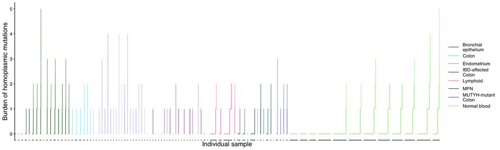

```r
homo_muts_per_sample<-n_near_homoplasmic_per_sample%>%
  mutate(dataset=name_conversion_vec[dataset])%>%
  unite(col = "Cohort_ID",dataset,exp_ID,sep="_",remove = F)%>%
  ggplot(aes(x=forcats::fct_reorder(factor(Sample),n_homo),y=n_homo,col=factor(dataset)))+
  #geom_point(size=0.3)+
  geom_line(aes(group=Cohort_ID))+
  facet_grid(~factor(Cohort_ID,levels=Sample_order),scales = "free",space = "free")+
  scale_color_manual(values = tissue_cols)+
  theme_classic()+
  my_markdown_theme+
  theme(axis.text.x=element_blank(),
        strip.text.x=element_blank(),axis.ticks.x=element_blank())+
  labs(x="Individual sample",col="",y="Burden of homoplasmic mutations")

homo_muts_per_sample
```

```r
save_plot(plot = homo_muts_per_sample,filename = paste0(plots_dir,"homo_muts_per_sample.pdf"),width=15,height=3)
```

## LINEAR REGRESSION MODEL

Do linear model just including the mean values from the adult blood and lymphoid data. Because these generally have large numbers of samples, the mean values are fairly accurate and the linear model is a reasonable way to assess the increased number of (near-) homoplasmic muts in lymphoid cells compare to HSCs of the same age.

Only include post development individuals (age > 20), which is the more constant phase of drift.

Assume that the lymphocytes have a fixed term for the increase in homoplasmic i.e. the slope is fixed.

```r
studies_to_include=c("blood","lymph")
blood_vs_lymph_homo_muts_dat<-n_near_homoplasmic_per_sample%>%
  group_by(dataset,exp_ID)%>%
  dplyr::summarise(n=n(),mean=mean(n_homo),var=var(n_homo),sd=sd(n_homo),.groups = "drop_last")%>%
  mutate(sem=sd/sqrt(n))%>%
  left_join(ref_df,by=c("dataset"="Cohort","exp_ID"="ID"))%>%
  filter(dataset%in%studies_to_include & Age>20)

lmer.blood_vs_lymph<-lme4::lmer(mean~Age+dataset + (1|exp_ID),data = blood_vs_lymph_homo_muts_dat)
coefs<-summary(lmer.blood_vs_lymph)$coefficients
coef_df<-data.frame(dataset=c("Normal blood","Lymphoid"),slope=rep(coefs['Age','Estimate'],2),intercept=c(coefs['(Intercept)','Estimate'],coefs['(Intercept)','Estimate']+coefs['datasetlymph','Estimate']))

coef_df
```

```
##        dataset       slope    intercept
## 1 Normal blood 0.004924677 -0.099075609
## 2     Lymphoid 0.004924677  0.003253265
```

Plot the data points with the regression lines.

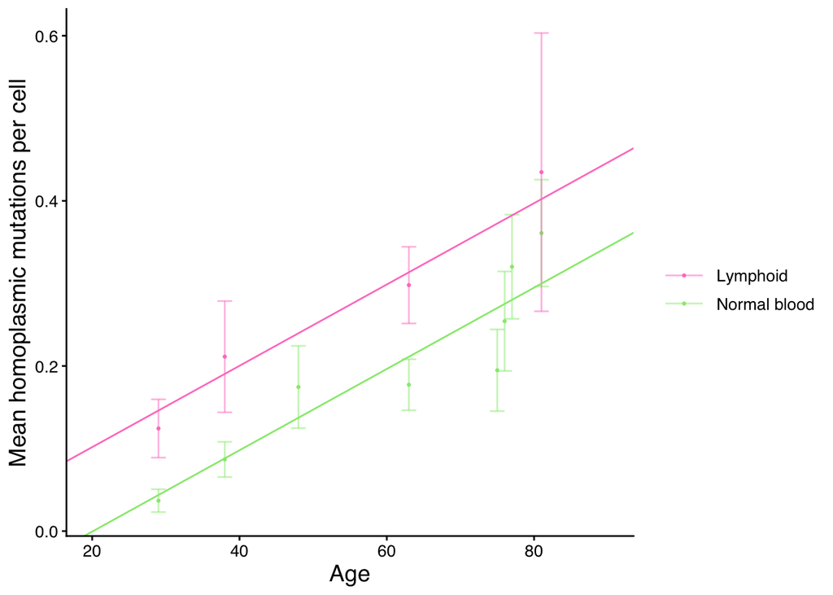

```r
HSC_vs_lymph_mean_homo_burden<-blood_vs_lymph_homo_muts_dat%>%
  mutate(dataset=name_conversion_vec[dataset])%>%
  ggplot(aes(x=Age,y=mean,ymin=(mean-1.96*sem),ymax=(mean+1.96*sem),col=dataset))+
  geom_point(size=0.5)+
  geom_errorbar(width=2,alpha=0.5)+
  geom_abline(aes(slope=slope,intercept=intercept,col=dataset),data = coef_df,show.legend = F)+
  scale_color_manual(values=tissue_cols)+
  scale_x_continuous(limits=c(20,90))+
  labs(x="Age",y="Mean homoplasmic mutations per cell",col="")+
  theme_classic()+
  my_markdown_theme

HSC_vs_lymph_mean_homo_burden
```

```r
save_plot(plot = HSC_vs_lymph_mean_homo_burden,filename = paste0(plots_dir,"HSC_vs_lymph_mean_homo_burden.pdf"),width=3,height=2)
```

### POISSON REGRESSION MODEL

Perform a poisson regression model for this data to get a sense of different rates of drift in different tissues Uses a GLM mixed-effects model Fixed effects are ‘Age’ and the ‘Tissue’ (defined by the dataset) Random effects are the individual ID and the Age Include only the adult data as this is the more linear region of the data

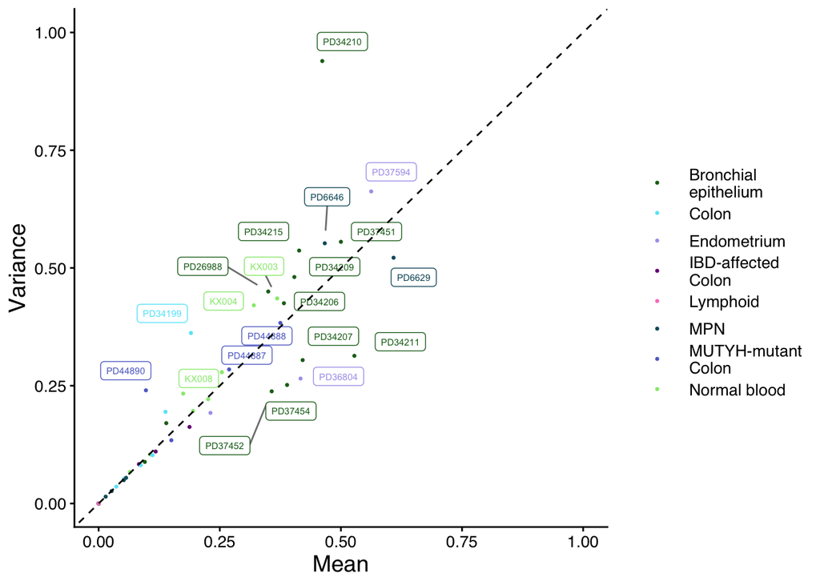

```r
#Check mean vs variance: generally very similar, therefore poisson regression is reasonable
Mean_vs_Variance_plot<-n_near_homoplasmic_per_sample%>%
  group_by(exp_ID)%>%
  dplyr::summarise(dataset=dataset[1],n=n(),Mean=mean(n_homo),Variance=var(n_homo),.groups = "drop_last")%>%
  filter(n>10)%>%
  mutate(dataset=name_conversion_vec[dataset])%>%
  ggplot(aes(x=Mean,y=Variance,col=dataset))+
  ggrepel::geom_label_repel(aes(label = exp_ID),box.padding   = 0.35, point.padding = 0.5, size=2, segment.color = 'grey50',show.legend=F)+
  geom_point(size=0.5)+
  geom_abline(linetype=2)+
  scale_color_manual(values=tissue_cols)+
  scale_x_continuous(limits=c(0,1))+
  scale_y_continuous(limits=c(0,1))+
  theme_classic()+
  my_markdown_theme+
  labs(col="")

Mean_vs_Variance_plot
```

```r
save_plot(plot = Mean_vs_Variance_plot,filename = paste0(plots_dir,"homo_muts_mean_vs_variance.pdf"),width=3,height=2)
```

Perform the poisson regression on the full data set. Here, each data point is an individual sample, individual is a random effect.

```r
minimum_age_for_regression=20
n_near_homoplasmic_per_sample_FILT<-n_near_homoplasmic_per_sample%>%filter(Age>=minimum_age_for_regression)%>%mutate(logAge=log(Age+0.1))

n_near_homoplasmic_per_sample_FILT$Age_scaled<-scale(n_near_homoplasmic_per_sample_FILT$Age)
glmer.res<-lme4::glmer(n_homo~Age_scaled+dataset+(1+Age_scaled|exp_ID),family=poisson(link="log"),data=n_near_homoplasmic_per_sample_FILT)
summary(glmer.res)
```

```
## Generalized linear mixed model fit by maximum likelihood (Laplace
##   Approximation) [glmerMod]
##  Family: poisson  ( log )
## Formula: n_homo ~ Age_scaled + dataset + (1 + Age_scaled | exp_ID)
##    Data: n_near_homoplasmic_per_sample_FILT
##
##       AIC       BIC    logLik -2*log(L)  df.resid
##    6500.7    6582.1   -3238.3    6476.7      6538
##
## Scaled residuals:
##     Min      1Q  Median      3Q     Max
## -0.9718 -0.4611 -0.3088 -0.2265  8.6031
##
## Random effects:
##  Groups Name        Variance Std.Dev. Corr
##  exp_ID (Intercept) 0.14873  0.3857
##         Age_scaled  0.02929  0.1711   -1.00
## Number of obs: 6550, groups:  exp_ID, 78
##
## Fixed effects:
##              Estimate Std. Error z value Pr(>|z|)
## (Intercept)  -1.91499    0.13668 -14.011  < 2e-16 ***
## Age_scaled    0.50624    0.09198   5.504 3.71e-08 ***
## datasetHL    -0.46369    0.31497  -1.472  0.14097
## datasetKY     0.40039    0.13799   2.902  0.00371 **
## datasetLM     1.23606    0.24284   5.090 3.58e-07 ***
## datasetlymph  0.62001    0.08697   7.129 1.01e-12 ***
## datasetNW    -0.35754    0.22892  -1.562  0.11831
## datasetPR     0.64537    0.38139   1.692  0.09062 .
## datasetSO    -0.27693    0.30168  -0.918  0.35863
## ---
## Signif. codes:  0 '***' 0.001 '**' 0.01 '*' 0.05 '.' 0.1 ' ' 1
##
## Correlation of Fixed Effects:
##             (Intr) Ag_scl dtstHL dtstKY dtstLM dtstly dtstNW dtstPR
## Age_scaled  -0.715
## datasetHL   -0.422  0.295
## datasetKY   -0.472  0.048  0.207
## datasetLM   -0.702  0.532  0.305  0.296
## datastlymph -0.089  0.037  0.037  0.070  0.042
## datasetNW   -0.446  0.193  0.192  0.277  0.323  0.041
## datasetPR   -0.396  0.306  0.168  0.173  0.285  0.033  0.172
## datasetSO   -0.512  0.395  0.221  0.225  0.384  0.039  0.226  0.206
## optimizer (Nelder_Mead) convergence code: 0 (OK)
## Model failed to converge with max|grad| = 0.0229 (tol = 0.002, component 1)
##   See ?lme4::convergence and ?lme4::troubleshooting.
```

```r
car::vif(glmer.res)
```

```
##                GVIF Df GVIF^(1/(2*Df))
## Age_scaled 1.622278  1        1.273687
## dataset    1.622278  7        1.035164
```

```r
overdispersion_ratio <- sum(residuals(glmer.res, type = "pearson")^2) / df.residual(glmer.res)
overdispersion_ratio
```

```
## [1] 1.043719
```

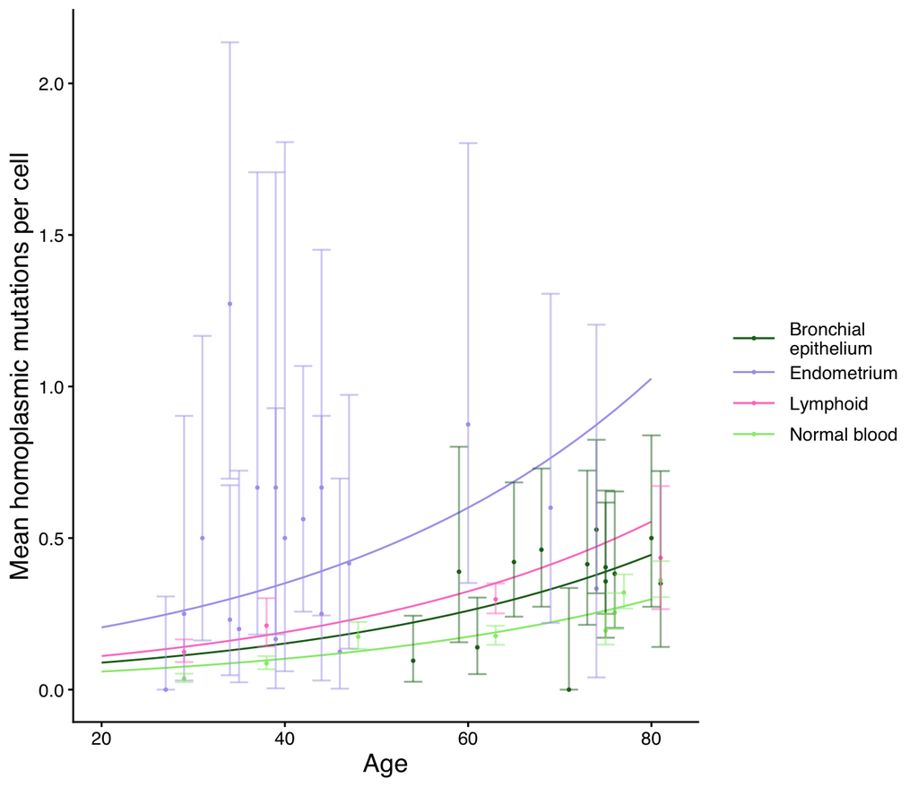

```r
#Now generate the regression curves for plotting by using the 'predict' function on test data

# get the scaling parameters used when creatining Age_scaled in the model data
age_center <- attr(n_near_homoplasmic_per_sample_FILT$Age_scaled, "scaled:center")
age_scale <- attr(n_near_homoplasmic_per_sample_FILT$Age_scaled, "scaled:scale")

ages_to_cover <- seq(minimum_age_for_regression, 80, 2)
tissues_to_cover <- c("blood", "lymph", "KY", "LM")

test_data <- data.frame(
  dataset = rep(tissues_to_cover, each = length(ages_to_cover)),
  exp_ID = ids::ids(length(ages_to_cover) * length(tissues_to_cover)),
  Age = rep(ages_to_cover, times = length(tissues_to_cover))
) %>%
  mutate(
    logAge = log(Age),
    Age_scaled = (Age - age_center) / age_scale
  )

test_data$n_homo <- exp(predict(glmer.res, newdata = test_data, allow.new.levels = TRUE))

#Visualize the regression model on top of the data for the selected tissues
#Functions to calculate the upper/ lower CI of the mean from count data
get_upper_CI<-function (X, conf.level=0.95) {alpha = 1 - conf.level; upper <- 0.5 * qchisq(1-alpha/2, 2*X+2)}
get_lower_CI<-function (X, conf.level=0.95) {alpha = 1 - conf.level; lower <- 0.5 * qchisq(alpha/2, 2*X)}

data_vs_regression<-n_near_homoplasmic_per_sample%>%
  group_by(dataset,exp_ID)%>%
  dplyr::summarise(n_samp=n(),mean=mean(n_homo),total_homo=sum(n_homo),.groups = "drop_last")%>%
  dplyr::mutate(CI_low=get_lower_CI(total_homo)/n_samp,CI_high=get_upper_CI(total_homo)/n_samp)%>%
    left_join(ref_df,by=c("dataset"="Cohort","exp_ID"="ID"))%>%
  filter(Age>=minimum_age_for_regression)%>%
  filter(dataset%in%tissues_to_cover)%>%
  mutate(dataset=name_conversion_vec[dataset])%>%
  ggplot(aes(x=Age,y=mean,ymin=CI_low,ymax=CI_high,col=dataset))+
  geom_point(size=0.5)+
  geom_line(aes(x=Age,y=mean,col = dataset),data = test_data%>%dplyr::rename("mean"=n_homo)%>%mutate(dataset=name_conversion_vec[dataset]),inherit.aes = F)+
  geom_errorbar(width=2,alpha=0.5)+
  scale_color_manual(values = tissue_cols)+
  labs(x="Age",y="Mean homoplasmic mutations per cell",col="")+
  theme_classic()+
  my_markdown_theme

data_vs_regression
```

```r
save_plot(plot = data_vs_regression,filename = paste0(plots_dir,"data_vs_regression.pdf"),width=3,height=2)
```

Visualize the tissue-specific coefficients (relative to blood)

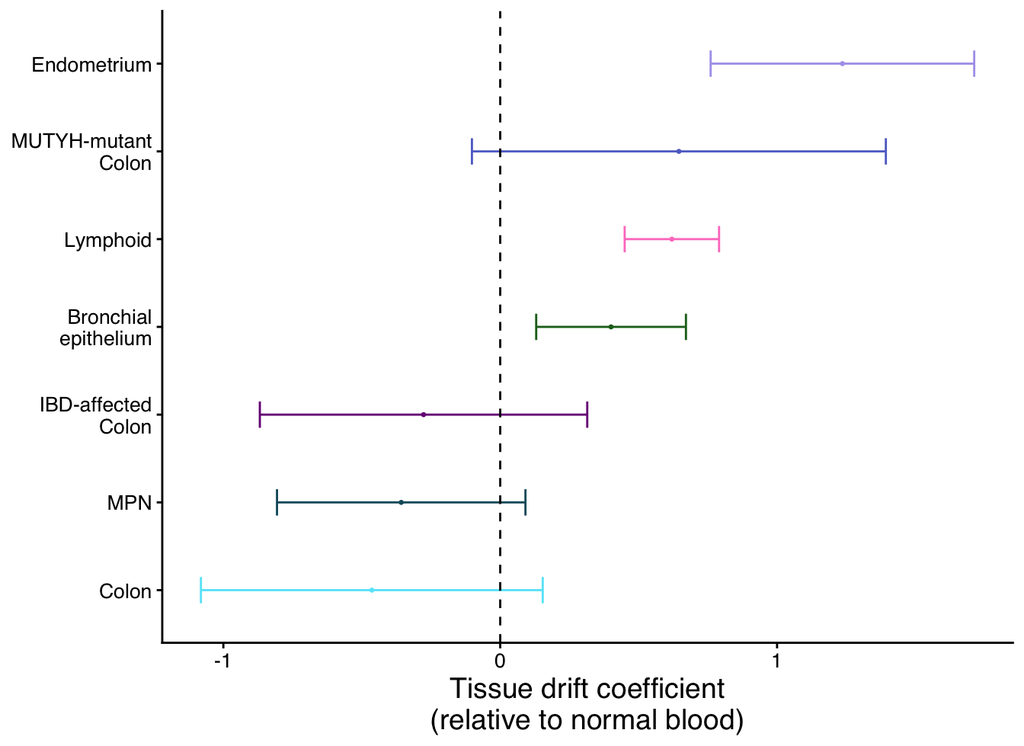

```r
homo_muts_glm_coefficients<-summary(glmer.res)$coefficients%>%
  as.data.frame()%>%
  tibble::rownames_to_column(var="Coefficient")%>%
  filter(grepl("dataset",Coefficient))%>%
  mutate(Coefficient=name_conversion_vec[gsub("dataset","",Coefficient)])%>%
  mutate(Coefficient=factor(Coefficient))%>%
  ggplot(aes(y=forcats::fct_reorder(Coefficient,Estimate),
             col=Coefficient,
             x=Estimate,xmin=(Estimate-1.96*`Std. Error`),
             xmax=(Estimate+1.96*`Std. Error`)))+
  geom_point(size=0.5)+
  scale_color_manual(values = tissue_cols)+
  geom_errorbar(width = 0.3)+
  geom_vline(xintercept = 0,linetype=2)+
  theme_classic()+
  my_markdown_theme+
  theme(axis.title.y=element_blank(),legend.position = "none")+
  labs(x="Tissue drift coefficient\n(relative to normal blood)")

homo_muts_glm_coefficients
```

```r
save_plot(plot = homo_muts_glm_coefficients,filename = paste0(plots_dir,"homo_muts_glm_coefficients.pdf"),width=2,height=2.2)
```

### Cell type-specific analysis for the lymphoid cells

Filter out only the blood & lymphoid cell types & enhance with the cell type information for the lymphoid cells. This is data primarily from the Machado et al paper. We can therefore see whether the increased drift is related to B/T cell type? Or naive/ memory cell type?

```r
minimum_age_for_regression=20
n_homoplasmic_lymph_type<-n_near_homoplasmic_per_sample_FILT%>%
  filter(dataset%in%c("blood","lymph"))%>%
  left_join(colony_info%>%dplyr::select("Sample"=colony,"exp_ID"=Donor,CellType,Cell.type2),by=c("Sample","exp_ID"))%>%
  mutate(Cell.type2=ifelse(dataset=="blood","HSPC",Cell.type2))

Cell.types<-c("HSPC" ,"Naive B","Naive T","Memory B","Memory T","Treg")
cell_type_cols<-c("#1d6d1f",colorRampPalette(c("#fd81c8","#5f70cc","#aea2eb"))(5))
names(cell_type_cols)<-Cell.types

n_homoplasmic_lymph_type$Age_scaled=scale(n_homoplasmic_lymph_type$Age)

#Now do the glmer poisson regression model using the cell type, not just lymphoid vs blood
glmer.res_blood_vs_lymph_subdivided<-lme4::glmer(n_homo~Age_scaled+Cell.type2+(1+Age_scaled|exp_ID),family=poisson(link="log"),data=n_homoplasmic_lymph_type)
```

```
## boundary (singular) fit: see help('isSingular')
```

```r
summary(glmer.res_blood_vs_lymph_subdivided)
```

```
## Generalized linear mixed model fit by maximum likelihood (Laplace
##   Approximation) [glmerMod]
##  Family: poisson  ( log )
## Formula: n_homo ~ Age_scaled + Cell.type2 + (1 + Age_scaled | exp_ID)
##    Data: n_homoplasmic_lymph_type
##
##       AIC       BIC    logLik -2*log(L)  df.resid
##    4990.9    5056.3   -2485.5    4970.9      5114
##
## Scaled residuals:
##     Min      1Q  Median      3Q     Max
## -0.8080 -0.4667 -0.3206 -0.2386  8.1426
##
## Random effects:
##  Groups Name        Variance Std.Dev. Corr
##  exp_ID (Intercept) 0.00000  0.0000
##         Age_scaled  0.01983  0.1408    NaN
## Number of obs: 5124, groups:  exp_ID, 8
##
## Fixed effects:
##                    Estimate Std. Error z value Pr(>|z|)
## (Intercept)        -1.93418    0.06378 -30.326  < 2e-16 ***
## Age_scaled          0.52840    0.06896   7.662 1.83e-14 ***
## Cell.type2Memory B  0.66524    0.17792   3.739 0.000185 ***
## Cell.type2Memory T  0.54524    0.16953   3.216 0.001299 **
## Cell.type2Naive B   0.23852    0.21135   1.129 0.259083
## Cell.type2Naive T   0.59068    0.10057   5.873 4.27e-09 ***
## Cell.type2Treg      0.93144    0.32224   2.891 0.003846 **
## ---
## Signif. codes:  0 '***' 0.001 '**' 0.01 '*' 0.05 '.' 0.1 ' ' 1
##
## Correlation of Fixed Effects:
##             (Intr) Ag_scl Cl.2MB Cl.2MT Cl.2NB Cl.2NT
## Age_scaled  -0.367
## Cll.typ2MmB -0.136  0.014
## Cll.typ2MmT -0.178  0.033  0.070
## Cll.typ2NvB -0.148  0.006  0.056  0.072
## Cll.typ2NvT -0.327  0.084  0.116  0.149  0.129
## Cll.typ2Trg -0.101 -0.007  0.036  0.050  0.048  0.089
## optimizer (Nelder_Mead) convergence code: 0 (OK)
## boundary (singular) fit: see help('isSingular')
```

Now generate the regression curves for plotting by using the ‘predict’ function on test data

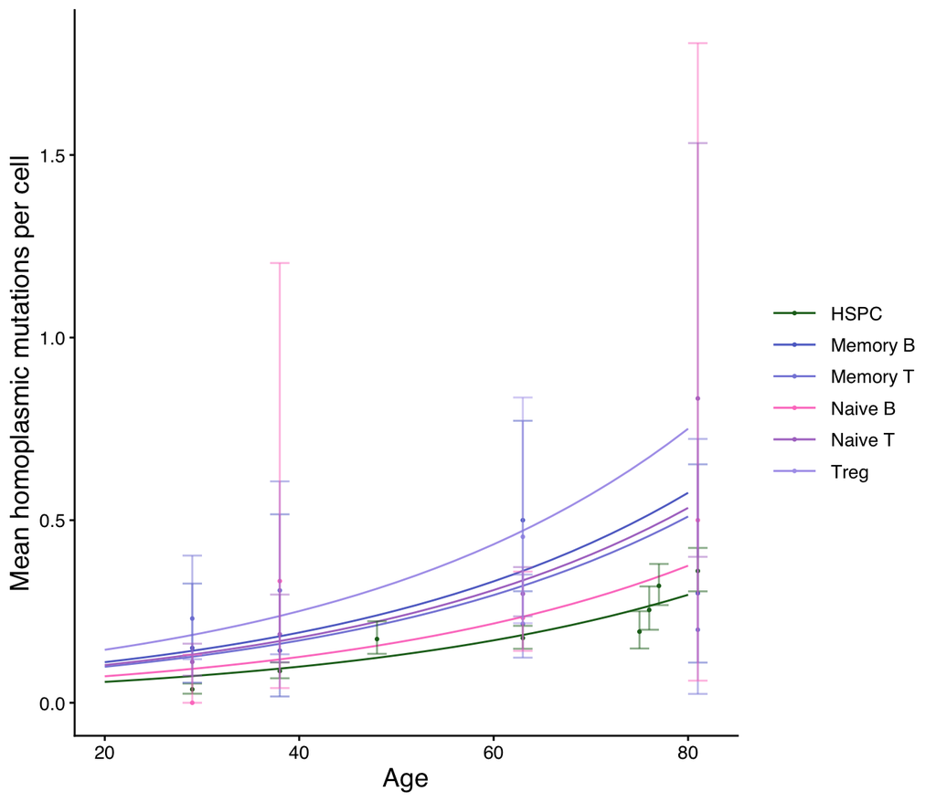

```r
# get the scaling parameters used when creatining Age_scaled in the model data
age_center <- attr(n_homoplasmic_lymph_type$Age_scaled, "scaled:center")
age_scale <- attr(n_homoplasmic_lymph_type$Age_scaled, "scaled:scale")

ages_to_cover <- seq(minimum_age_for_regression, 80, 2)
tissues_to_cover<-unique(n_homoplasmic_lymph_type$Cell.type2)

test_data <- data.frame(
  Cell.type2 = rep(tissues_to_cover, each = length(ages_to_cover)),
  exp_ID = ids::ids(length(ages_to_cover) * length(tissues_to_cover)),
  Age = rep(ages_to_cover, times = length(tissues_to_cover))
) %>%
  mutate(
    logAge = log(Age),
    Age_scaled = (Age - age_center) / age_scale
  )

test_data$n_homo <- exp(predict(glmer.res_blood_vs_lymph_subdivided, newdata = test_data, allow.new.levels = TRUE))

#Visualize the regression model on top of the data for the selected tissues
#Functions to calculate the upper/ lower CI of the mean from count data
get_upper_CI<-function (X, conf.level=0.95) {alpha = 1 - conf.level; upper <- 0.5 * qchisq(1-alpha/2, 2*X+2)}
get_lower_CI<-function (X, conf.level=0.95) {alpha = 1 - conf.level; lower <- 0.5 * qchisq(alpha/2, 2*X)}

data_vs_regression_lymph_subdivided<-n_homoplasmic_lymph_type%>%
  group_by(Age,Cell.type2,exp_ID)%>%
  dplyr::summarise(Age=Age[1],n_samp=n(),mean=mean(n_homo),total_homo=sum(n_homo),.groups = "drop_last")%>%
  dplyr::mutate(CI_low=get_lower_CI(total_homo)/n_samp,CI_high=get_upper_CI(total_homo)/n_samp)%>%
  filter(Age>=minimum_age_for_regression)%>%
  ggplot(aes(x=Age,y=mean,ymin=CI_low,ymax=CI_high,col=Cell.type2))+
  geom_point(size=0.5)+
  geom_line(aes(x=Age,y=n_homo,col = Cell.type2),data = test_data,inherit.aes = F)+
  geom_errorbar(width=2,alpha=0.5)+
  scale_color_manual(values = cell_type_cols)+
  labs(x="Age",y="Mean homoplasmic mutations per cell",col="")+
  theme_classic()+
  my_markdown_theme
data_vs_regression_lymph_subdivided
```

```r
save_plot(plot = data_vs_regression_lymph_subdivided,filename = paste0(plots_dir,"data_vs_regression_lymph_subdivided.pdf"),width=3,height=2)
```

Visualize the coefficients for these different lymphocyte types.

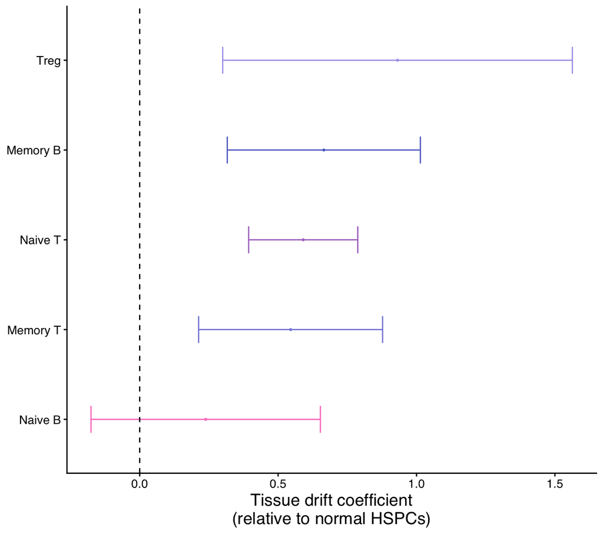

```r
# Visualize the lymphoid celltype-specific coefficients (relative to blood)
blood_vs_lymph_subdivided_homo_muts_glm_coefficients<-summary(glmer.res_blood_vs_lymph_subdivided)$coefficients%>%
  as.data.frame()%>%
  tibble::rownames_to_column(var="Coefficient")%>%
  filter(grepl("Cell.type2",Coefficient))%>%
  mutate(Coefficient=gsub("Cell.type2","",Coefficient))%>%
  mutate(Coefficient=factor(Coefficient))%>%
  ggplot(aes(y=forcats::fct_reorder(Coefficient,Estimate),
             col=Coefficient,
             x=Estimate,xmin=(Estimate-1.96*`Std. Error`),
             xmax=(Estimate+1.96*`Std. Error`)))+
  geom_point(size=0.5)+
  scale_color_manual(values = cell_type_cols)+
  geom_errorbar(width = 0.3)+
  geom_vline(xintercept = 0,linetype=2)+
  theme_classic()+
  my_markdown_theme+
  theme(axis.title.y=element_blank(),legend.position = "none")+
  labs(x="Tissue drift coefficient\n(relative to normal HSPCs)")

blood_vs_lymph_subdivided_homo_muts_glm_coefficients
```

```r
save_plot(plot = blood_vs_lymph_subdivided_homo_muts_glm_coefficients,filename = paste0(plots_dir,"blood_vs_lymph_subdivided_homo_muts_glm_coefficients.pdf"),width=2,height=2.2)
```

Note that there were initial attempts to repeat the Wright-Fisher model based ABC model that we performed on blood. However, the distributions clearly did not fit the assumptions implicity in that model (i.e. a constant population size and mutation rate) leading to unstable, uninformative results.

While the code for these attempts are in some original analysis scripts they are not included here.